# Project6 Red Wine Analysis

### Description Two

As we see higher Quality correlates to higher alcohol content  
and lower density.

### Plot Three

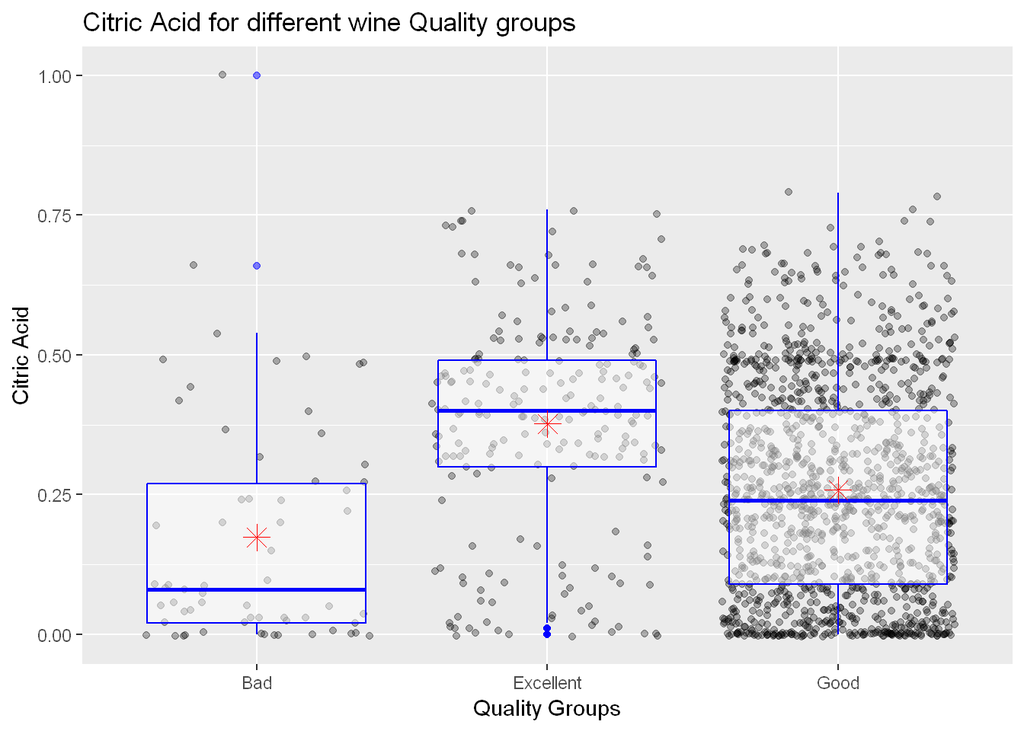

# Reflection

As seen from initial Quality ranking in this dataset we don’t have neither  
‘very bad’ not ‘very excellent’ wines. So we can’t see what qualities and  
characteristics are typical for exceptional (both ways) wines.

Most of our samples come from average ‘Good’ wines which limits our abitily  
to make correct predicitions about quality.

I found that: - Alcohol is very important factor in Quality group. Most ‘Excellent’ wines  
have 11%-12% content (minimum alcohol content in our samples is 8.4%) - Alcohol and density are negatively correlated which is due to chemistry. - Sulphates and sulfites are added to wine to preserve taste, so it’s unlikely to find decent wine without these ingredients. - The acidity is very important factor but it has to be balanced to avoid  
tart or too sweet taste.

This analysis is highly liited by uneven quality distribution and as  
linea model shows, provided factors only explaine 32% of quality variance.

I’ve checked few resourses about wine to get some guidance about wine quality  
and tasting and found interesting information which confirmes my  
analysis:

### The additionsl information:

**WIKI**: In wine tasting, humans are least sensitive to the taste of sweetness (in contrast to sensitivity to bitterness or sourness) with the majority of the  
population being able to detect sugar or “sweetness” in wines between 1% and  
2.5% residual sugar. Additionally, other components of wine such as acidity and  
tannins can mask the perception of sugar in the wine. https://en.wikipedia.org/wiki/Sugars_in_wine#In_wine_tasting

The acidity in wine is an important component in the quality and taste  
of the wine. It adds a sharpness to the flavors and is detected most readily  
by a prickling sensation on the sides of the tongue and a mouth-watering  
aftertaste. Of particular importance is the balance of acidity versus the sweetness of the wine (the leftover residual sugar) and the more bitter  
components of the wine (most notably tannins but also includes other  
phenolics). A wine with too much acidity will taste excessively sour and sharp.  
A wine with too little acidity will taste flabby and flat, with less defined  
flavors. https://en.wikipedia.org/wiki/Acids_in_wine#In_wine_tasting

High alcohol levels come from a high amount of sugar in the fermentation  
process, which the yeast converts into ethanol. https://vincarta.com/blog/choose-best-red-wine/